# matplotlib

matplotlib简介

译自[这里](https://github.com/rougier/matplotlib-tutorial)，做适当修改

[figure not shown]

*Photo by Scott Webb on Unsplash*

# 简介

matplotlib可能是2D绘图最常用的Python包，它提供了快速的方法对数据可视化，这篇文章介绍了最常用的例子。

## pyplot

pyplot为matplotlib面向对象的绘图库提供了一个方便的接口。它是在Matlab(TM)的基础上建立的。因此，pyplot中的大多数绘图命令都具有Matlab(TM)类似的参数。重要的命令通过交互式示例进行解释。

# 简单绘图

我们准备在同一个plot上画出sin函数和cos函数，从默认设置出发，一步一步进行完善。

## 准备数据

```python
import numpy as np
import matplotlib.pyplot as plt

X = np.linspace(-np.pi,np.pi,256,endpoint=True)
C,S = np.cos(X),np.sin(X)
```

## 以默认设置绘图

Documentation

[plot tutorial](https://matplotlib.org/users/pyplot_tutorial.html)

[plot() command](https://matplotlib.org/api/pyplot_api.html#matplotlib.pyplot.plot)

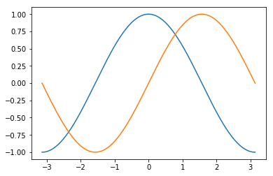

```python
# cosine(x)
plt.plot(X,C) # plot x and y using default line style and color
#sine(x)
plt.plot(X,S)
plt.show()
```

一般情况下我们不需要更改matplotlib的默认值，当然你可以根据实际情况来更改matplotlib的默认值以实现更好的效果，比如figure size,dpi, line width, color , style, axes, axis , grid properties, text , font properties等等。

Documentation

[Customizing matplotlib](https://matplotlib.org/users/customizing.html)

## 改变colors和line widths

Documentation

[Controlling line properties](https://matplotlib.org/users/pyplot_tutorial.html#controlling-line-properties)

[Line API](https://matplotlib.org/api/artist_api.html#matplotlib.lines.Line2D)

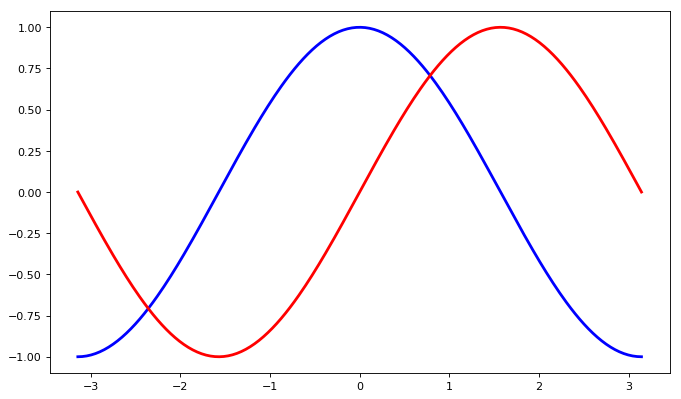

```python
plt.figure(figsize=(10,6),dpi=80) # DPI -> Dots Per Inch
plt.plot(X,C,color="blue",linewidth=2.5,linestyle="-")
plt.plot(X,S,color="red",linewidth=2.5,linestyle="-")
plt.show()
```

## 设置limits

Documentation

[xlim() command](http://matplotlib.sourceforge.net/api/pyplot_api.html#matplotlib.pyplot.xlim)

[ylim() command](http://matplotlib.sourceforge.net/api/pyplot_api.html#matplotlib.pyplot.ylim)

改变limits（坐标轴长度）以看清所有数据点。

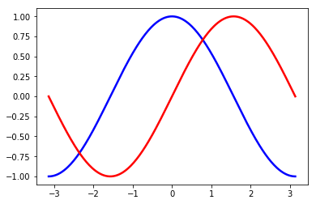

```python
plt.xlim(X.min()*1.1,X.max()*1.1)
plt.ylim(C.min()*1.1,C.max()*1.1)
plt.plot(X, C, color="blue", linewidth=2.5, linestyle="-")
plt.plot(X, S, color="red", linewidth=2.5, linestyle="-")
plt.show()
```

## 设置ticks

Documentation

[xticks() command](http://matplotlib.sourceforge.net/api/pyplot_api.html#matplotlib.pyplot.xticks)

[yticks() command](http://matplotlib.sourceforge.net/api/pyplot_api.html#matplotlib.pyplot.yticks)

[Tick container](http://matplotlib.sourceforge.net/users/artists.html#axis-container)

[Tick locating and formatting](http://matplotlib.sourceforge.net/api/ticker_api.html)

我们希望坐标轴只显示sine和cosine函数关心的点(+/-π,+/-π/2),使用ticks来设置。

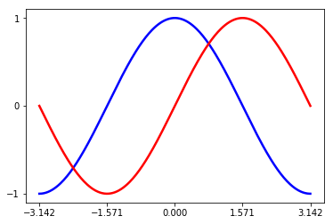

```python
plt.plot(X,C,color='blue',linewidth=2.5,linestyle="-")
plt.plot(X,S,color='red',linewidth=2.5,linestyle='-')
plt.xticks([-np.pi,-np.pi/2,0,np.pi/2,np.pi])
plt.yticks([-1,0,1])
plt.show()
```

## 设置tick标签

Documentation

[Working with text](http://matplotlib.sourceforge.net/users/index_text.html)

[xticks() command](http://matplotlib.sourceforge.net/api/pyplot_api.html#matplotlib.pyplot.xticks)

[yticks() command](http://matplotlib.sourceforge.net/api/pyplot_api.html#matplotlib.pyplot.yticks)

[set_xticklabels()](http://matplotlib.sourceforge.net/api/axes_api.html?#matplotlib.axes.Axes.set_xticklabels)

[set_yticklabels()](http://matplotlib.sourceforge.net/api/axes_api.html?#matplotlib.axes.Axes.set_yticklabels)

在设置tick值时，还可以在第二个参数列表中提供相应的标签，比如我们希望使用-π而不是-3.141这样的形式。注意，我们将使用latex来很好地呈现标签。

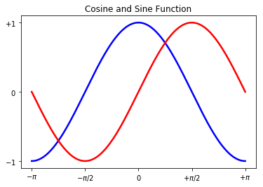

```python
plt.plot(X,C,color='blue',linewidth=2.5,linestyle="-")
plt.plot(X,S,color='red',linewidth=2.5,linestyle='-')
plt.xticks([-np.pi, -np.pi/2, 0, np.pi/2, np.pi],
       [r'$-\pi$', r'$-\pi/2$', r'$0$', r'$+\pi/2$', r'$+\pi$'])

plt.yticks([-1, 0, +1],
       [r'$-1$', r'$0$', r'$+1$'])
plt.title("Cosine and Sine Function")

plt.show()
```

## 移动spine

Documentation

[Spines](http://matplotlib.sourceforge.net/api/spines_api.html#matplotlib.spines)

[Axis container](http://matplotlib.sourceforge.net/users/artists.html#axis-container)

[Transformations tutorial](http://matplotlib.sourceforge.net/users/transforms_tutorial.html)

Spines是线，分别用来连接ticks（图 “Cosine and Sine Function”中的左线和底线）和标记数据区域边界（图 “Cosine and Sine Function”的顶线和右线）。现在我们想把它们放在图中间，方法是设置顶线和右线的颜色为None来使这两条线消失，将左线和底线移动至图中间。

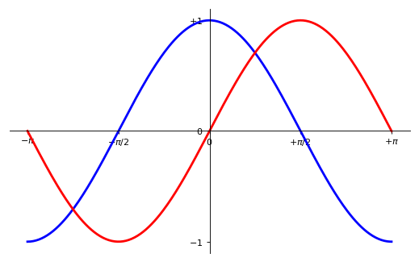

```python
plt.figure(figsize=(8,5),dpi=80)
ax = plt.subplot(111)

plt.plot(X,C,color='blue',linewidth=2.5,linestyle='-')
plt.plot(X,S,color='red',linewidth=2.5,linestyle='-')

ax.spines['right'].set_color('None')
ax.spines['top'].set_color('None')
ax.xaxis.set_ticks_position('bottom')
ax.spines['bottom'].set_position(('data',0))
ax.yaxis.set_ticks_position('left')
ax.spines['left'].set_position(('data',0))

plt.xticks([-np.pi, -np.pi/2, 0, np.pi/2, np.pi],
       [r'$-\pi$', r'$-\pi/2$', r'$0$', r'$+\pi/2$', r'$+\pi$'])

plt.yticks([-1, 0, +1],
       [r'$-1$', r'$0$', r'$+1$'])

plt.show()
```

## 添加legend(图例)

Documentation

[Legend guide](http://matplotlib.sourceforge.net/users/legend_guide.html)

[legend() command](http://matplotlib.sourceforge.net/api/pyplot_api.html#matplotlib.pyplot.legend)

[Legend API](http://matplotlib.sourceforge.net/api/legend_api.html#matplotlib.legend.Legend)

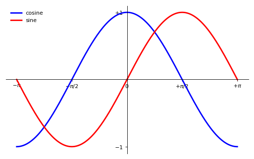

```python
plt.figure(figsize=(8,5), dpi=80)
ax = plt.subplot(111)
ax.spines['right'].set_color('none')
ax.spines['top'].set_color('none')
ax.xaxis.set_ticks_position('bottom')
ax.spines['bottom'].set_position(('data',0))
ax.yaxis.set_ticks_position('left')
ax.spines['left'].set_position(('data',0))

plt.plot(X, C, color="blue", linewidth=2.5, linestyle="-", label="cosine")
plt.plot(X, S, color="red", linewidth=2.5, linestyle="-", label="sine")

plt.xlim(X.min()*1.1, X.max()*1.1)
plt.xticks([-np.pi, -np.pi/2, 0, np.pi/2, np.pi],
           [r'$-\pi$', r'$-\pi/2$', r'$0$', r'$+\pi/2$', r'$+\pi$'])

plt.ylim(C.min()*1.1,C.max()*1.1)
plt.yticks([-1, +1],
           [r'$-1$', r'$+1$'])

plt.legend(loc='upper left', frameon=False)

plt.show()
```

## 给一些点添加注释

Documentation

[Annotating axis](http://matplotlib.sourceforge.net/users/annotations_guide.html)

[annotate() command](http://matplotlib.sourceforge.net/api/pyplot_api.html#matplotlib.pyplot.annotate)

让我们给一些感兴趣的点添加注释，比如 2π/3 ，我们想注释该点的cos和sin值。首先，我们在曲线和点状直线上做标记，然后使用注释命令使用箭头展示注释文本。

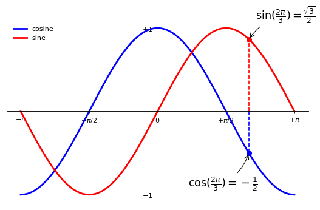

```python
plt.figure(figsize=(8,5), dpi=80)
ax = plt.subplot(111)
ax.spines['right'].set_color('none')
ax.spines['top'].set_color('none')
ax.xaxis.set_ticks_position('bottom')
ax.spines['bottom'].set_position(('data',0))
ax.yaxis.set_ticks_position('left')
ax.spines['left'].set_position(('data',0))

X = np.linspace(-np.pi, np.pi, 256,endpoint=True)
C,S = np.cos(X), np.sin(X)

plt.plot(X, C, color="blue", linewidth=2.5, linestyle="-", label="cosine")
plt.plot(X, S, color="red", linewidth=2.5, linestyle="-",  label="sine")

plt.xlim(X.min()*1.1, X.max()*1.1)
plt.xticks([-np.pi, -np.pi/2, 0, np.pi/2, np.pi],
           [r'$-\pi$', r'$-\pi/2$', r'$0$', r'$+\pi/2$', r'$+\pi$'])

plt.ylim(C.min()*1.1,C.max()*1.1)
plt.yticks([-1, +1],
           [r'$-1$', r'$+1$'])

t = 2*np.pi/3
plt.plot([t,t],[0,np.cos(t)],
         color ='blue',  linewidth=1.5, linestyle="--")
plt.scatter([t,],[np.cos(t),], 50, color ='blue')
plt.annotate(r'$\cos(\frac{2\pi}{3})=-\frac{1}{2}$',
             xy=(t, np.cos(t)),  xycoords='data',
             xytext=(-90, -50), textcoords='offset points', fontsize=16,
             arrowprops=dict(arrowstyle="->", connectionstyle="arc3,rad=.2"))

plt.plot([t,t],[0,np.sin(t)],
         color ='red',  linewidth=1.5, linestyle="--")
plt.scatter([t,],[np.sin(t),], 50, color ='red')
plt.annotate(r'$\sin(\frac{2\pi}{3})=\frac{\sqrt{3}}{2}$',
             xy=(t, np.sin(t)),  xycoords='data',
             xytext=(+10, +30), textcoords='offset points', fontsize=16,
             arrowprops=dict(arrowstyle="->", connectionstyle="arc3,rad=.2"))

plt.legend(loc='upper left', frameon=False)
plt.show()
```

## 魔鬼藏于细节（细节决定成败）

Documentation

[Artists](http://matplotlib.sourceforge.net/api/artist_api.html)

[BBox](http://matplotlib.sourceforge.net/api/artist_api.html#matplotlib.text.Text.set_bbox)

tick标签被两条曲线挡住了，很难看清楚。我们可以使标签变大或者调整透明度，这样曲线与标签都能看清楚。

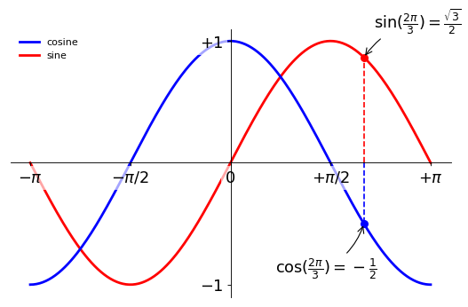

```python
plt.figure(figsize=(8,5), dpi=80)
ax = plt.subplot(111)
ax.spines['right'].set_color('none')
ax.spines['top'].set_color('none')
ax.xaxis.set_ticks_position('bottom')
ax.spines['bottom'].set_position(('data',0))
ax.yaxis.set_ticks_position('left')
ax.spines['left'].set_position(('data',0))

X = np.linspace(-np.pi, np.pi, 256,endpoint=True)
C,S = np.cos(X), np.sin(X)

plt.plot(X, C, color="blue", linewidth=2.5, linestyle="-", label="cosine",
         zorder=-1)
plt.plot(X, S, color="red", linewidth=2.5, linestyle="-",  label="sine",
         zorder=-2)


plt.xlim(X.min()*1.1, X.max()*1.1)
plt.xticks([-np.pi, -np.pi/2, 0, np.pi/2, np.pi],
           [r'$-\pi$', r'$-\pi/2$', r'$0$', r'$+\pi/2$', r'$+\pi$'])

plt.ylim(C.min()*1.1,C.max()*1.1)
plt.yticks([-1, +1],
           [r'$-1$', r'$+1$'])

plt.legend(loc='upper left', frameon=False)

t = 2*np.pi/3
plt.plot([t,t],[0,np.cos(t)],
         color ='blue',  linewidth=1.5, linestyle="--")
plt.scatter([t,],[np.cos(t),], 50, color ='blue')
plt.annotate(r'$\sin(\frac{2\pi}{3})=\frac{\sqrt{3}}{2}$',
             xy=(t, np.sin(t)),  xycoords='data',
             xytext=(+10, +30), textcoords='offset points', fontsize=16,
             arrowprops=dict(arrowstyle="->", connectionstyle="arc3,rad=.2"))

plt.plot([t,t],[0,np.sin(t)],
         color ='red',  linewidth=1.5, linestyle="--")
plt.scatter([t,],[np.sin(t),], 50, color ='red')
plt.annotate(r'$\cos(\frac{2\pi}{3})=-\frac{1}{2}$',
             xy=(t, np.cos(t)),  xycoords='data',
             xytext=(-90, -50), textcoords='offset points', fontsize=16,
             arrowprops=dict(arrowstyle="->", connectionstyle="arc3,rad=.2"))

for label in ax.get_xticklabels() + ax.get_yticklabels():
    label.set_fontsize(16)
    label.set_bbox(dict(facecolor='white', edgecolor='None', alpha=0.65 ))

plt.show()
```

# Figures,Subplots,Axes and Ticks

在开始之前，强烈建议先看下知乎的这篇文章[python matplotlib中axes与axis的区别?](https://www.zhihu.com/question/51745620)

$\bf{〝}$一个完整的画图过程可以使用两套工具分别来实现：

```
. 函数式编程思想：调用pyplot中的 plot() 函数和 xlim() 函数。

. 对象式编程思想：使用生成的Subplot对象的两种方法 .plot 和 .set_xlim方法。
```

$\bf{〞}$ -----知乎$\bf{·}$[禹洋](https://www.zhihu.com/question/51745620/answer/231113561)

到此为止，我们大部分使用的是第一种方式，这对快速画图是很方便的。事实上，我们可以使用figure,subplot,axes显式的施加更多控制。 *A figure in matplotlib means the whole window in the user interface. Within this figure there can be subplots. While subplot positions the plots in a regular grid, axes allows free placement within the figure. Both can be useful depending on your intention.* 我们已经以一种隐式的方式调用过figure和subplot了，当我们调用plot时，matplotlib调用gca()来获取当前axes，gca反过来调用gcf()来获取当前figrue.如果没有figure，则调用figure()生成一个，严格地说，生成一个subplot(111)。

## Figures

图是GUI中标题为“figure #”的窗口。图的编号是从1开始的，而不是普通的Python方法从0开始。这显然是跟随了MATLAB风格的。下面是一些figure的参数。

| Argument | Default | Description |
| --- | --- | --- |
| num | 1 | number of figure |
| figsize | figure.figsize | figure size in in inches (width, height) |
| dpi | figure.dpi | resolution in dots per inch |
| facecolor | figure.facecolor | color of the drawing background |
| edgecolor | figure.edgecolor | color of edge around the drawing background |
| frameon | True | draw figure frame or not |

大多数情况下使用默认值。只有$num$是经常变化的。

当你使用GUI时，您可以通过单击右上角的×来关闭figure。你还可以通过调用close以编程方式关闭它。根据参数的不同，它关闭(1)当前图(无参数)、(2)特定的图(图号或图实例作为参数)或(3)所有图(all作为参数)。

与其他对象一样，可以使用$set\_something$方法设置figure属性

## Subplots

使用subplot，你可以在规则网格中安排plots。你需要指定行和列的数量以及图的序号(在grid中的位置)。注意，gridspec命令是一个更强大的替代方法。

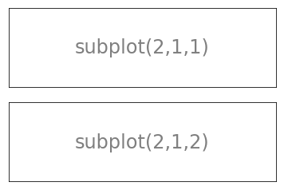

```python
from pylab import *

subplot(2,1,1)
xticks([]), yticks([])
text(0.5,0.5, 'subplot(2,1,1)',ha='center',va='center',size=24,alpha=.5)

subplot(2,1,2)
xticks([]), yticks([])
text(0.5,0.5, 'subplot(2,1,2)',ha='center',va='center',size=24,alpha=.5)

show()
```

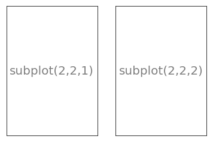

```python
subplot(1,2,1)
xticks([]), yticks([])
text(0.5,0.5, 'subplot(2,2,1)',ha='center',va='center',size=20,alpha=.5)

subplot(1,2,2)
xticks([]), yticks([])
text(0.5,0.5, 'subplot(2,2,2)',ha='center',va='center',size=20,alpha=.5)

show()
```

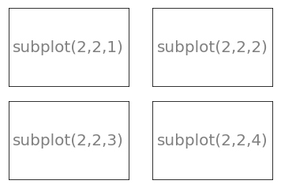

```python
subplot(2,2,1)
xticks([]), yticks([])
text(0.5,0.5, 'subplot(2,2,1)',ha='center',va='center',size=20,alpha=.5)

subplot(2,2,2)
xticks([]), yticks([])
text(0.5,0.5, 'subplot(2,2,2)',ha='center',va='center',size=20,alpha=.5)

subplot(2,2,3)
xticks([]), yticks([])
text(0.5,0.5, 'subplot(2,2,3)',ha='center',va='center',size=20,alpha=.5)

subplot(2,2,4)
xticks([]), yticks([])
text(0.5,0.5, 'subplot(2,2,4)',ha='center',va='center',size=20,alpha=.5)

show()
```

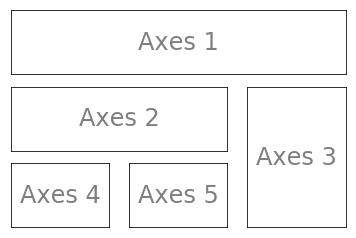

```python
import matplotlib.gridspec as gridspec

G = gridspec.GridSpec(3, 3)

axes_1 = subplot(G[0, :])
xticks([]), yticks([])
text(0.5,0.5, 'Axes 1',ha='center',va='center',size=24,alpha=.5)

axes_2 = subplot(G[1,:-1])
xticks([]), yticks([])
text(0.5,0.5, 'Axes 2',ha='center',va='center',size=24,alpha=.5)

axes_3 = subplot(G[1:, -1])
xticks([]), yticks([])
text(0.5,0.5, 'Axes 3',ha='center',va='center',size=24,alpha=.5)

axes_4 = subplot(G[-1,0])
xticks([]), yticks([])
text(0.5,0.5, 'Axes 4',ha='center',va='center',size=24,alpha=.5)

axes_5 = subplot(G[-1,-2])
xticks([]), yticks([])
text(0.5,0.5, 'Axes 5',ha='center',va='center',size=24,alpha=.5)
show()
```

## Axes

axes与subplot非常相似，但是axes可以放置在figure中的任何位置。我们可以使用axes实现多种位置关系的放置。

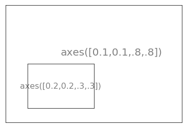

```python
axes([0.1,0.1,.8,.8])
xticks([]), yticks([])
text(0.6,0.6, 'axes([0.1,0.1,.8,.8])',ha='center',va='center',size=20,alpha=.5)

axes([0.2,0.2,.3,.3])
xticks([]), yticks([])
text(0.5,0.5, 'axes([0.2,0.2,.3,.3])',ha='center',va='center',size=16,alpha=.5)
show()
```

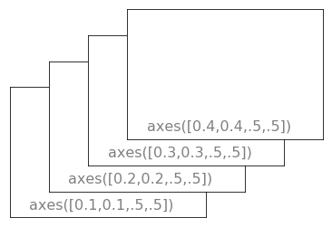

```python
axes([0.1,0.1,.5,.5])
xticks([]), yticks([])
text(0.1,0.1, 'axes([0.1,0.1,.5,.5])',ha='left',va='center',size=16,alpha=.5)

axes([0.2,0.2,.5,.5])
xticks([]), yticks([])
text(0.1,0.1, 'axes([0.2,0.2,.5,.5])',ha='left',va='center',size=16,alpha=.5)

axes([0.3,0.3,.5,.5])
xticks([]), yticks([])
text(0.1,0.1, 'axes([0.3,0.3,.5,.5])',ha='left',va='center',size=16,alpha=.5)

axes([0.4,0.4,.5,.5])
xticks([]), yticks([])
text(0.1,0.1, 'axes([0.4,0.4,.5,.5])',ha='left',va='center',size=16,alpha=.5)

# plt.savefig("../figures/axes-2.png",dpi=64)
show()
```

## Ticks

ticks的格式有时也很重要。Matplotlib提供了一个完全可配置的ticks系统。有一些ticks定位器来指定ticks应该出现在何处，以及ticks格式化器来给出所需的ticks外观。major ticks和minor ticks可以彼此独立定位和格式化。默认情况下，不显示minor ticks，也就是说，只有一个空列表，因为它是空定位器(见下面)。

| Class | Description |
| --- | --- |
| `NullLocator` | No ticks. |
| `IndexLocator` | Place a tick on every multiple of some base number of points plotted. |
| `FixedLocator` | Tick locations are fixed. |
| `LinearLocator` | Determine the tick locations. |
| `MultipleLocator` | Set a tick on every integer that is multiple of some base. |
| `AutoLocator` | Select no more than n intervals at nice locations. |
| `LogLocator` | Determine the tick locations for log axes. |

所有这些定位器都派生自基类matplotlib.ticker.Locator。你可以从它派生出你自己的定位器。将日期作为ticks进行处理尤其棘手。因此，matplotlib在matplotlib.date中提供了特殊的定位器。

# Animation(动画)

创建动画的工具从matplotlib 1.1版本开始引入的，等用到时再回来补充....

Sugar

[figure not shown]

*Photo by Markus Spiske on Unsplash*

你想了解Seaborn吗？

- [Better Plotting In Python With Seaborn](https://robinsones.github.io/Better-Plotting-in-Python-with-Seaborn/)
- [Python Seaborn Tutorial For Beginners](https://www.datacamp.com/community/tutorials/seaborn-python-tutorial#gs.UCr9qmE)